# Untitled

Sumeet Mishra

1/27/2019

```r
library(NHANES)
library(ggplot2)
library(broom)
library(arm)
nhanes<-(NHANES)

myvars1<-c("BPSysAve","Age","Gender")
myvars2<-c("BPSysAve","Height","Gender")
myvars3<-c("BPSysAve","Weight","Gender")

nhanes_age<-nhanes[myvars1]
nhanes_age$Age[ nhanes_age$Age > 80 ] = 80
nhanes_height<-nhanes[myvars2]
nhanes_weight<-nhanes[myvars3]
nhanes_age=nhanes_age[!(!complete.cases(nhanes_age)), ]
nhanes_height=nhanes_height[!(!complete.cases(nhanes_height)), ]
nhanes_weight=nhanes_weight[!(!complete.cases(nhanes_weight)), ]
```

## The NHANES library was loaded and the data is segregated into 3 models for Age,Height and Weight. For age model, if age found more than 80 then it was replaced with a value of 80. All the missing values were removed from the indivisual models.

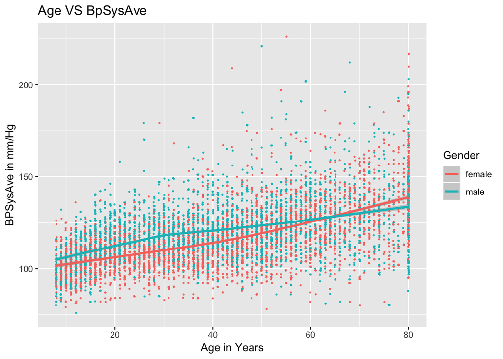

```r
ggplot(nhanes_age, aes(x = Age, y =BPSysAve,color=Gender)) + geom_jitter(height = 0.2, width = 0.1, size = 0.3) + geom_smooth(method='loess',method.args=list(degree=1))+xlab('Age in Years')+ylab('BPSysAve in mm/Hg')+ggtitle('Age VS BpSysAve')
```

## The main plot for ‘Age~BPSysAve’ was plotted. The findings from the plot-

## 1.The systolic blood pressure has an increasing trend for both males and females.

## 2.Males has a slightly more systolic blood pressure than females of the same age. However, at around age 65, the pressure of both males and females are almost same and for afterwards the pressure for females increased more than males.

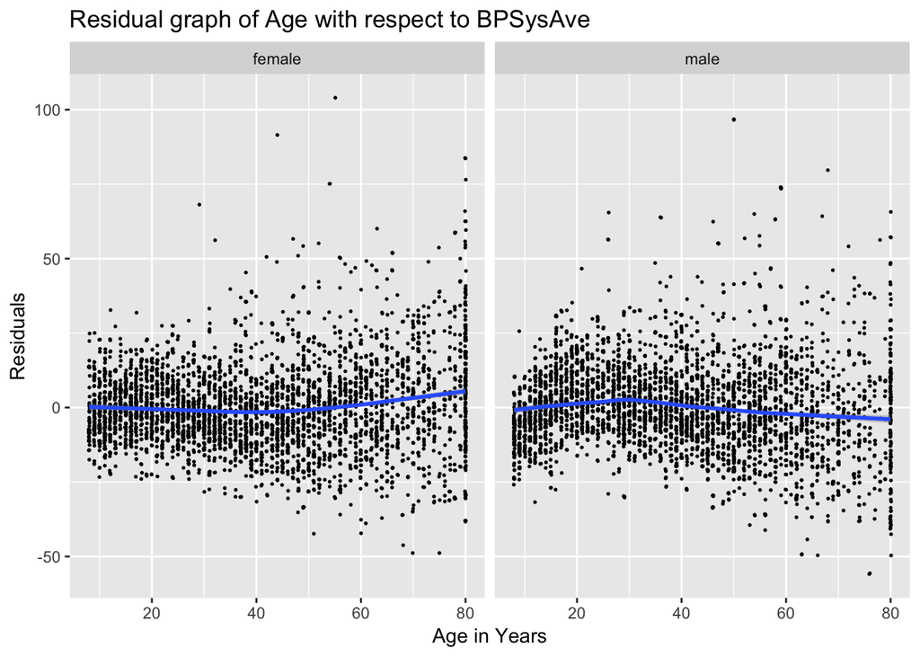

```r
nhanes_age.lm = lm(BPSysAve ~ Age+Gender, data = nhanes_age)
nhanes_age.lm.df = augment(nhanes_age.lm)
ggplot(nhanes_age.lm.df, aes(x =Age , y = .resid)) + geom_jitter(height = 0.3, width = 0.1, size = 0.3)+ facet_wrap(~ Gender) + geom_smooth(method='loess',method.args=list(degree=1))+xlab('Age in Years')+ylab('Residuals')+ggtitle('Residual graph of Age with respect to BPSysAve ')
```

```r
#display(nhanes_age.lm)
```

## From the residual plot for age we observed the trend on a linear model. The model describes and captures the trend well. So, we can conclude that linear model is a good model for this data. (Although other models may be good or better than linear model)

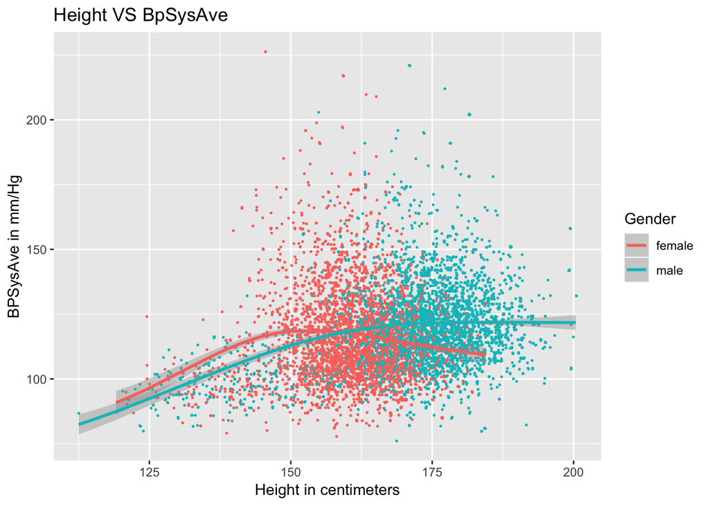

```r
ggplot(nhanes_height, aes(x = Height, y =BPSysAve,color=Gender)) + geom_jitter(height = 0.3, width = 0.1, size = 0.3) + geom_smooth(method='loess',method.args=list(degree=1))+xlab('Height in centimeters')+ylab('BPSysAve in mm/Hg')+ggtitle('Height VS BpSysAve')
```

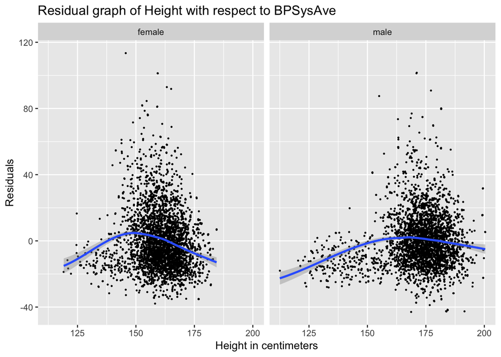

```r
nhanes_height.lm = lm(BPSysAve ~ Height + Gender, data = nhanes_height)

nhanes_height.lm.df = augment(nhanes_height.lm)

ggplot(nhanes_height.lm.df, aes(x =Height , y = .resid)) + geom_jitter(height = 0.3, width = 0.1, size = 0.3)+
  facet_wrap(~ Gender) + geom_smooth(method='loess',method.args=list(degree=1))+xlab('Height in centimeters')+ylab('Residuals')+ggtitle('Residual graph of Height with respect to BPSysAve ')
```

```r
#display(nhanes_height.lm)
```

## The residual plot for Height is drawn with linear model. It can be seen that linear model does not describe well the plot. But other models like sqaure model were tried which does not improve much the graph. Which means height alone is not a very good predictor of blood pressure.

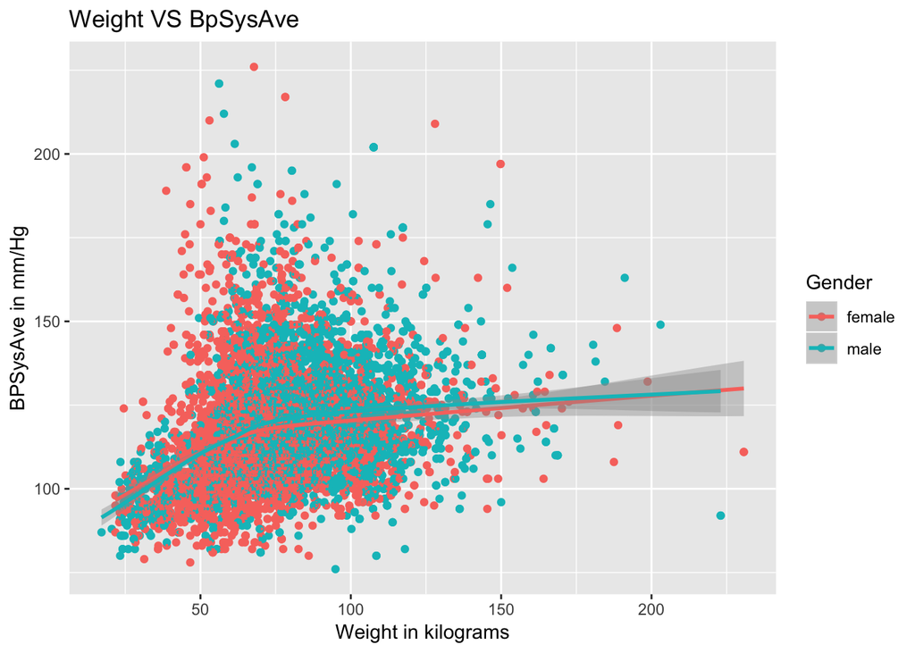

```r
ggplot(nhanes_weight, aes(x = Weight, y =BPSysAve,color=Gender)) + geom_point()  + geom_jitter(height = 0.1, width = 0.1, size = 0.1) +geom_smooth(method='loess',method.args=list(degree=1))+xlab('Weight in kilograms')+ylab('BPSysAve in mm/Hg')+ggtitle('Weight VS BpSysAve')
```

## The plot between ‘Weight~ BPSysAve’ was plotted. From the plot, it was observed that upto weight 75kg, the blood pressure increased a lot but afterwards it increased at steady pace. The graph does not show any significant difference between males and females.

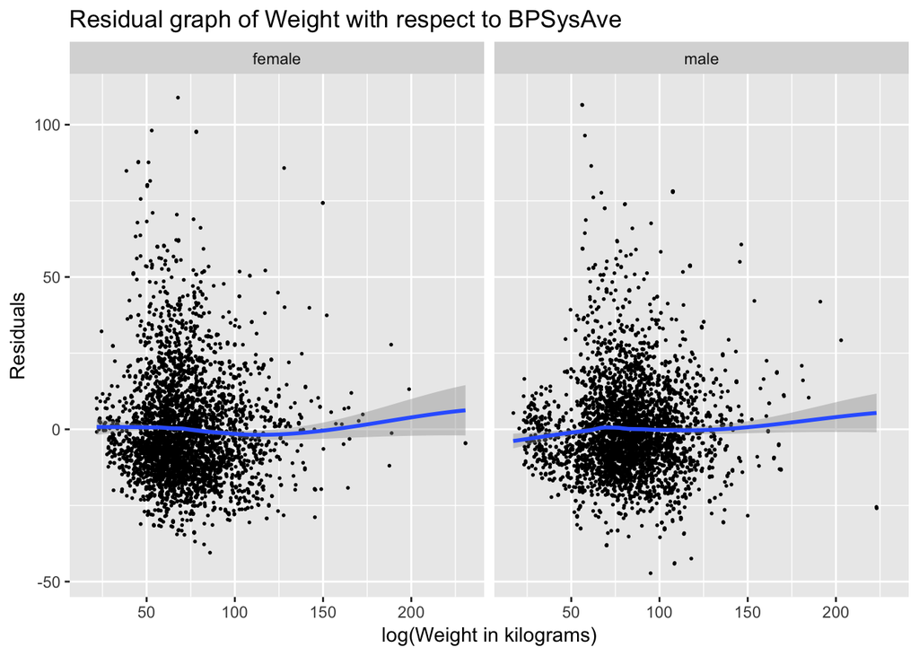

```r
nhanes_weight.lm = lm(BPSysAve ~ log(Weight) + Gender+Weight, data = nhanes_weight)
nhanes_weight.lm.df = augment(nhanes_weight.lm)
ggplot(nhanes_weight.lm.df, aes(x =Weight , y = .resid)) + geom_jitter(height = 0.3, width = 0.1, size = 0.3)+
  facet_wrap(~ Gender) + geom_smooth(method='loess',method.args=list(degree=1))+xlab('log(Weight in kilograms)')+ylab('Residuals')+ggtitle('Residual graph of Weight with respect to BPSysAve ')
```

```r
#display(nhanes_weight.lm)
```